# Get started with abstr

# Getting started

## Installing R

To generate new scenario files to import into A/B Street with the `abstr` R package, you need to have installed a stable version of [Rstudio and R](https://www.rstudio.com/products/rstudio/).

## Installing A/B Street

Install the [latest build](https://a-b-street.github.io/docs/user/index.html) of A/B Street for your platform. Or if you prefer, [build from source](https://a-b-street.github.io/docs/tech/dev/index.html), but it’s not necessary for any integration with the `abstr` package.

# Using `abstr`

Load the package as follows:

```r
library(abstr)
```

The input datasets include `sf` objects representing buildings, origin-destination (OD) data represented as desire lines and administrative zones representing the areas within which trips in the desire lines start and end. With the exception of OD data, each of the input datasets is readily available for most cities. The input datasets are illustrated in the plots below, which show example data shipped in the package, taken from the Seattle, U.S.

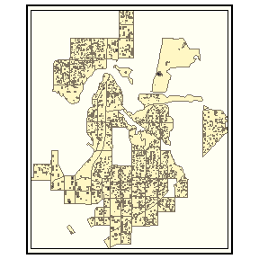

Example data that can be used as an input by functions in abstr to generate trip-level scenarios that can be imported by A/B Street.

```r
library(abstr)
library(tmap) # for map making
tm_shape(montlake_zones) + tm_polygons(col = "grey") +
  tm_shape(montlake_buildings) + tm_polygons(col = "blue")  +
tm_style("classic")
```

The map above is a graphical representation of the Montlake residential neighborhood in central Seattle, Washington. Here, `montlake_zones` represents neighborhood residential zones declared by Seattle local government and `montlake_buildings` being the accumulation of buildings listed in [OpenStreetMap](https://www.openstreetmap.org/#map=5/54.910/-3.432)

The final piece of the `abstr` puzzle is OD data.

```r
head(montlake_od)
```

```
#> # A tibble: 6 x 6
#>    o_id  d_id Drive Transit  Bike  Walk
#>   <dbl> <dbl> <int>   <int> <int> <int>
#> 1   281   361    23       1     2    14
#> 2   282   361    37       4     0    11
#> 3   282   369    14       3     0     8
#> 4   301   361    27       4     3    15
#> 5   301   368     6       2     1    16
#> 6   301   369    14       2     0    13
```

In this example, the first two columns correspond to the origin and destination zones in Montlake, with the subsequent columns representing the transport mode share between these zones.

```r
set.seed(42)
montlake_od_minimal = subset(montlake_od, o_id == "373" |o_id == "402" | o_id == "281" | o_id == "588" | o_id == "301" | o_id == "314")
output_sf = ab_scenario(
  od = montlake_od_minimal,
  zones = montlake_zones,
  zones_d = NULL,
  origin_buildings = montlake_buildings,
  destination_buildings = montlake_buildings,
  pop_var = 3,
  time_fun = ab_time_normal,
  output = "sf",
  modes = c("Walk", "Bike", "Drive", "Transit")
)
```

The `output_sf` object created above can be further transformed to match [A/B Street’s schema](https://a-b-street.github.io/docs/tech/dev/formats/scenarios.html) and visualised in A/B Street, or visualised in R (using the `tmap` package in the code chunk below):

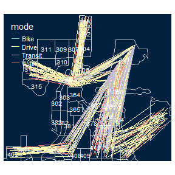

```r
tm_shape(output_sf) + tmap::tm_lines(col = "mode", lwd = .8, lwd.legeld.col = "black") +
  tm_shape(montlake_zones) + tmap::tm_borders(lwd = 1.2, col = "gray") +
  tm_text("id", size = 0.6) +
tm_style("cobalt")
```

Each line in the plot above represents a single trip, with the color representing each transport mode. Moreover, each trip is configured with an associated departure time, that can be represented in A/B Street.

The `ab_save` and `ab_json` functions conclude the `abstr` workflow by outputting a local JSON file, matching the [A/B Street’s schema](https://a-b-street.github.io/docs/tech/dev/formats/scenarios.html).

```r
output_json = ab_json(output_sf, time_fun = ab_time_normal, scenario_name = "Montlake Example")
ab_save(output_json, f = "montlake_scenarios.json")
```

Let’s see what is in the file:

```r
file.edit("ab_scenario.json")
```

The first trip schedule should look something like this, matching [A/B Street’s schema](https://a-b-street.github.io/docs/tech/dev/formats/).

```json
{
  "scenario_name": "Montlake Example",
  "people": [
    {
      "trips": [
        {
          "departure": 317760000,
          "origin": {
            "Position": {
              "longitude": -122.3139,
              "latitude": 47.667
            }
          },
          "destination": {
            "Position": {
              "longitude": -122.3187,
              "latitude": 47.6484
            }
          },
          "mode": "Walk",
          "purpose": "Shopping"
        }
      ]
    }
```

# Importing scenario files into A/B Street

After generating a `montlake_scenario.json`, you can import and simulate it as follows.

1. Run A/B Street, and choose “Sandbox” on the title screen.
2. If necessary, change the map to the Montlake district of Seattle, or whichever map your JSON scenario covers.
3. Change the scenario from the default “weekday” pattern. Choose “import JSON scenario,” then select your `montlake_scenario.json` file.

After you successfully import this file once, it will be available in the list of scenarios, under the “Montlake Example” name, or whatever `name` specified by the JSON file.

# Projects supporting `abstr`

Several open source R packages enabled the creation of `abstr`.

These include:

- jsonlite for awesome JSON parsing and generation
- magrittr for magic `%>%` pipe-command chaining
- sf for simple feature support
- tibble for strict data-frame declaration
- tidyr for all things data cleaning

# Context

To further understand the methods and motivations behind `abstr`, it helps to have some context. The package builds on the ecosystem of open source software for geospatial data ([FOSS4G](https://foss4g.org/)) and packages such as [`stplanr`](https://docs.ropensci.org/stplanr/) for working with transport data in R. `stplanr` was developed to support development of the the Propensity to Cycle Tool ([PCT](https://www.pct.bike/)), an open source transport planning system for England and Wales. The PCT [package](https://github.com/ITSLeeds/pct) enables access to the data generated by the PCT project, plus scenario of change modeling (not forecasting) at the origin-destination level, which can provide results at regions, local, route and route network levels.

[figure not shown]

The PCT provides a range of deterministic scenarios of change, such as `go_dutch` (where cycling levels matches that of the Netherlands), `gender_eq` (where there is equal levels of cycling among Female and Males) and `gov_target` (where cycling levels reflect that of UK government current targets). An academic [paper](https://www.jtlu.org/index.php/jtlu/article/view/862) on the PCT provides further detail on the motivations for and methods underlying the project. In 2018 the beasty `stplanr` (sustainable transport planning) package and R journal [article](https://journal.r-project.org/archive/2018/RJ-2018-053/RJ-2018-053.pdf) came on the scene, and further provided functions for solving common problems in transport planning and modeling, as well as advocating a transparency in tool usage within the transport planning paradigm.

[figure not shown]

Finally, on the R side, in 2021 the `od` package was released which provided functions for working with origin-destination data. A central focus in all of the packages and papers mentioned above is to provide open access transport tools to support data driven transport policies based on an objective and transparent evidence base.

For more on the history motivating the development of the `abstr` package see the [`pct_to_abstr` vignette](https://a-b-street.github.io/abstr/articles/pct_to_abstr.html)